# Online Education System Exploration

## Introduction

Pandemic has influenced all spheres of the humanity. COVID-19 impacted the education vertical in larger manner. Traditional classroom environment plays a very vital role in molding the life of an individual. Bond nurtured in the early ages of the life acts as the great moral support in the latter stages of the journey. As the pandemic has forced us into online education, this data collection aims to analyze the impact of online education. To check out the satisfactory level of the learners, review was conducted.

## Preliminary Wrangling

```python
# Import all packages and set plots to be embedded inline
import numpy as np
import pandas as pd
import matplotlib.pyplot as plt
from matplotlib import rcParams
import seaborn as sns
sns.set_style("darkgrid")
plt.rcParams["figure.figsize"] = (12,4)
plt.rcParams["figure.dpi"] = 144
pd.set_option('display.max_columns', 30)
%matplotlib inline
```

#### Loading the Dataset

```python
# Load in the dataset into a pandas dataframe
online_review = pd.read_csv('ONLINE EDUCATION SYSTEM REVIEW.csv')
```

```python
online_review.head(10)
```

|  | Gender | Home Location | Level of Education | Age(Years) | Number of Subjects | Device type used to attend classes | Economic status | Family size | Internet facility in your locality | Are you involved in any sports? | Do elderly people monitor you? | Study time (Hours) | Sleep time (Hours) | Time spent on social media (Hours) | Interested in Gaming? | Have separate room for studying? | Engaged in group studies? | Average marks scored before pandemic in traditional classroom | Your interaction in online mode | Clearing doubts with faculties in online mode | Interested in? | Performance in online | Your level of satisfaction in Online Education |
| --- | --- | --- | --- | --- | --- | --- | --- | --- | --- | --- | --- | --- | --- | --- | --- | --- | --- | --- | --- | --- | --- | --- | --- |
| 0 | Male | Urban | Under Graduate | 18 | 11 | Laptop | Middle Class | 4 | 5 | No | Yes | 3 | 6 | 1 | No | No | No | 91-100 | 1 | 1 | Practical | 6 | Average |
| 1 | Male | Urban | Under Graduate | 19 | 7 | Laptop | Middle Class | 4 | 1 | Yes | Yes | 7 | 5 | 1 | Yes | Yes | No | 91-100 | 1 | 1 | Theory | 3 | Bad |
| 2 | Male | Rural | Under Graduate | 18 | 5 | Laptop | Middle Class | 5 | 2 | No | Yes | 6 | 7 | 1 | No | Yes | No | 71-80 | 1 | 1 | Both | 6 | Bad |
| 3 | Male | Urban | Under Graduate | 18 | 5 | Laptop | Middle Class | 4 | 4 | Yes | Yes | 3 | 6 | 2 | No | No | yes | 91-100 | 1 | 2 | Theory | 4 | Bad |
| 4 | Male | Rural | Under Graduate | 18 | 5 | Laptop | Middle Class | 4 | 3 | No | No | 8 | 7 | 2 | Yes | Yes | yes | 81-90 | 3 | 3 | Both | 6 | Average |
| 5 | Male | Urban | Under Graduate | 18 | 5 | Laptop | Middle Class | 4 | 4 | Yes | Yes | 3 | 6 | 2 | No | No | yes | 91-100 | 1 | 1 | Theory | 2 | Bad |
| 6 | Male | Urban | Under Graduate | 19 | 5 | Laptop | Middle Class | 5 | 5 | No | No | 2 | 6 | 3 | Yes | Yes | yes | 81-90 | 4 | 3 | Both | 6 | Average |
| 7 | Male | Urban | Under Graduate | 17 | 4 | Laptop | Middle Class | 4 | 4 | Yes | Yes | 4 | 8 | 6 | No | Yes | No | 61-70 | 3 | 3 | Practical | 6 | Average |
| 8 | Female | Urban | Under Graduate | 19 | 5 | Laptop | Middle Class | 4 | 4 | No | Yes | 6 | 6 | 2 | No | Yes | yes | 81-90 | 4 | 1 | Both | 9 | Bad |
| 9 | Female | Rural | Under Graduate | 20 | 9 | Laptop | Middle Class | 4 | 3 | No | Yes | 4 | 7 | 2 | No | No | No | 81-90 | 3 | 2 | Theory | 6 | Average |

#### Assessing the Dataset

```python
# Overview of data shape and composition
print(online_review.shape)
print(online_review.dtypes)
```

```
(1033, 23)
Gender                                                           object
Home Location                                                    object
Level of Education                                               object
Age(Years)                                                        int64
Number of Subjects                                                int64
Device type used to attend classes                               object
Economic status                                                  object
Family size                                                       int64
Internet facility in your locality                                int64
Are you involved in any sports?                                  object
Do elderly people monitor you?                                   object
Study time (Hours)                                                int64
Sleep time (Hours)                                                int64
Time spent on social media (Hours)                                int64
Interested in Gaming?                                            object
Have separate room for studying?                                 object
Engaged in group studies?                                        object
Average marks scored before pandemic in traditional classroom    object
Your interaction in online mode                                   int64
Clearing doubts with faculties in online mode                     int64
Interested in?                                                   object
Performance in online                                             int64
Your level of satisfaction in Online Education                   object
dtype: object
```

```python
# Descriptive statistics for numeric variables
online_review.describe()
```

|  | Age(Years) | Number of Subjects | Family size | Internet facility in your locality | Study time (Hours) | Sleep time (Hours) | Time spent on social media (Hours) | Your interaction in online mode | Clearing doubts with faculties in online mode | Performance in online |
| --- | --- | --- | --- | --- | --- | --- | --- | --- | --- | --- |
| count | 1033.000000 | 1033.00000 | 1033.000000 | 1033.000000 | 1033.000000 | 1033.000000 | 1033.000000 | 1033.000000 | 1033.000000 | 1033.000000 |
| mean | 19.798645 | 7.03485 | 4.413359 | 3.586641 | 4.325266 | 6.947725 | 2.636980 | 2.930300 | 2.833495 | 6.696031 |
| std | 3.199158 | 2.81034 | 1.236750 | 1.026063 | 2.134233 | 1.324039 | 1.859625 | 1.105387 | 1.163629 | 1.920048 |
| min | 9.000000 | 1.00000 | 2.000000 | 1.000000 | 1.000000 | 1.000000 | 1.000000 | 1.000000 | 1.000000 | 2.000000 |
| 25% | 18.000000 | 6.00000 | 4.000000 | 3.000000 | 3.000000 | 6.000000 | 1.000000 | 2.000000 | 2.000000 | 6.000000 |
| 50% | 19.000000 | 7.00000 | 4.000000 | 4.000000 | 4.000000 | 7.000000 | 2.000000 | 3.000000 | 3.000000 | 7.000000 |
| 75% | 20.000000 | 8.00000 | 5.000000 | 4.000000 | 6.000000 | 8.000000 | 3.000000 | 4.000000 | 4.000000 | 8.000000 |
| max | 40.000000 | 20.00000 | 10.000000 | 5.000000 | 10.000000 | 10.000000 | 10.000000 | 5.000000 | 5.000000 | 10.000000 |

```python
online_review.info()
```

```
<class 'pandas.core.frame.DataFrame'>
RangeIndex: 1033 entries, 0 to 1032
Data columns (total 23 columns):
 #   Column                                                         Non-Null Count  Dtype
---  ------                                                         --------------  -----
 0   Gender                                                         1033 non-null   object
 1   Home Location                                                  1033 non-null   object
 2   Level of Education                                             1033 non-null   object
 3   Age(Years)                                                     1033 non-null   int64
 4   Number of Subjects                                             1033 non-null   int64
 5   Device type used to attend classes                             1033 non-null   object
 6   Economic status                                                1033 non-null   object
 7   Family size                                                    1033 non-null   int64
 8   Internet facility in your locality                             1033 non-null   int64
 9   Are you involved in any sports?                                1033 non-null   object
 10  Do elderly people monitor you?                                 1033 non-null   object
 11  Study time (Hours)                                             1033 non-null   int64
 12  Sleep time (Hours)                                             1033 non-null   int64
 13  Time spent on social media (Hours)                             1033 non-null   int64
 14  Interested in Gaming?                                          1033 non-null   object
 15  Have separate room for studying?                               1033 non-null   object
 16  Engaged in group studies?                                      1033 non-null   object
 17  Average marks scored before pandemic in traditional classroom  1033 non-null   object
 18  Your interaction in online mode                                1033 non-null   int64
 19  Clearing doubts with faculties in online mode                  1033 non-null   int64
 20  Interested in?                                                 1033 non-null   object
 21  Performance in online                                          1033 non-null   int64
 22  Your level of satisfaction in Online Education                 1033 non-null   object
dtypes: int64(10), object(13)
memory usage: 185.7+ KB
```

```python
# renaming certain columns
online_review.rename(columns = {'Your level of satisfaction in Online Education':'Satifaction level in O.E',
                                'Your interaction in online mode':'Online mode interaction',
                               'Internet facility in your locality':'Internet facility'}, inplace=True)
```

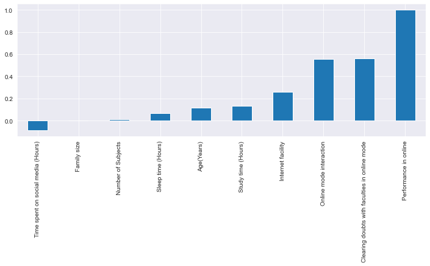

```python
#A quick look into the data to observe numeric features relationship with online performance
online_review.corr()['Performance in online'].sort_values().plot(kind='bar',figsize=(12,4));
```

```python
# Re-encoding certain column
dict = {1:'very_bad', 2:'bad', 3:'fair', 4:'good', 5:'very_good'}
online_review['Internet facility'].replace(dict, inplace = True)
online_review['Online mode interaction'].replace(dict, inplace = True)
online_review['Clearing doubts with faculties in online mode'].replace(dict, inplace = True)
```

```python
# convert the cols above into ordered categorical types
ordinal_var_dict = {'Internet facility': ['very_bad','bad','fair','good','very_good'],
                    'Online mode interaction': ['very_bad','bad','fair','good','very_good'],
                    'Clearing doubts with faculties in online mode': ['very_bad','bad','fair','good','very_good'],
                  'Satifaction level in O.E': ['Bad', 'Average', 'Good']}

for var in ordinal_var_dict:
    ordered_var = pd.api.types.CategoricalDtype(ordered = True,
                                                categories = ordinal_var_dict[var])
    online_review[var] = online_review[var].astype(ordered_var)
```

```python
# Scale online performance as percentage
online_review['Performance in online']= (online_review['Performance in online']/10)*100
```

```python
# Take the average of the range feature of Average marks scored before pandemic in traditional classroomas
#And convert to percentage:
online_review[['min_average','max_average']] = online_review['Average marks scored before pandemic in traditional classroom'].str.split('-',expand=True)
online_review['min_average']=online_review['min_average'].astype('int')
online_review['max_average']=online_review['max_average'].astype('int')
online_review['Performance in classroom'] = ((online_review['max_average'] + online_review['min_average'])/2)
```

```python
online_review.head(3)
```

|  | Gender | Home Location | Level of Education | Age(Years) | Number of Subjects | Device type used to attend classes | Economic status | Family size | Internet facility | Are you involved in any sports? | Do elderly people monitor you? | Study time (Hours) | Sleep time (Hours) | Time spent on social media (Hours) | Interested in Gaming? | Have separate room for studying? | Engaged in group studies? | Average marks scored before pandemic in traditional classroom | Online mode interaction | Clearing doubts with faculties in online mode | Interested in? | Performance in online | Satifaction level in O.E | min_average | max_average | Performance in classroom |
| --- | --- | --- | --- | --- | --- | --- | --- | --- | --- | --- | --- | --- | --- | --- | --- | --- | --- | --- | --- | --- | --- | --- | --- | --- | --- | --- |
| 0 | Male | Urban | Under Graduate | 18 | 11 | Laptop | Middle Class | 4 | very_good | No | Yes | 3 | 6 | 1 | No | No | No | 91-100 | very_bad | very_bad | Practical | 60.0 | Average | 91 | 100 | 95.5 |
| 1 | Male | Urban | Under Graduate | 19 | 7 | Laptop | Middle Class | 4 | very_bad | Yes | Yes | 7 | 5 | 1 | Yes | Yes | No | 91-100 | very_bad | very_bad | Theory | 30.0 | Bad | 91 | 100 | 95.5 |
| 2 | Male | Rural | Under Graduate | 18 | 5 | Laptop | Middle Class | 5 | bad | No | Yes | 6 | 7 | 1 | No | Yes | No | 71-80 | very_bad | very_bad | Both | 60.0 | Bad | 71 | 80 | 75.5 |

```python
# Saved cleaned data
online_review.to_csv('ONLINE EDUCATION SYSTEM REVIEW CLEAN.csv', index=False)
```

```python
online_review.describe()
```

|  | Age(Years) | Number of Subjects | Family size | Study time (Hours) | Sleep time (Hours) | Time spent on social media (Hours) | Performance in online | min_average | max_average | Performance in classroom |
| --- | --- | --- | --- | --- | --- | --- | --- | --- | --- | --- |
| count | 1033.000000 | 1033.00000 | 1033.000000 | 1033.000000 | 1033.000000 | 1033.000000 | 1033.000000 | 1033.000000 | 1033.000000 | 1033.000000 |
| mean | 19.798645 | 7.03485 | 4.413359 | 4.325266 | 6.947725 | 2.636980 | 66.960310 | 73.351404 | 82.352372 | 77.851888 |
| std | 3.199158 | 2.81034 | 1.236750 | 2.134233 | 1.324039 | 1.859625 | 19.200477 | 14.187608 | 14.182631 | 14.185111 |
| min | 9.000000 | 1.00000 | 2.000000 | 1.000000 | 1.000000 | 1.000000 | 20.000000 | 0.000000 | 10.000000 | 5.000000 |
| 25% | 18.000000 | 6.00000 | 4.000000 | 3.000000 | 6.000000 | 1.000000 | 60.000000 | 71.000000 | 80.000000 | 75.500000 |
| 50% | 19.000000 | 7.00000 | 4.000000 | 4.000000 | 7.000000 | 2.000000 | 70.000000 | 71.000000 | 80.000000 | 75.500000 |
| 75% | 20.000000 | 8.00000 | 5.000000 | 6.000000 | 8.000000 | 3.000000 | 80.000000 | 81.000000 | 90.000000 | 85.500000 |
| max | 40.000000 | 20.00000 | 10.000000 | 10.000000 | 10.000000 | 10.000000 | 100.000000 | 91.000000 | 100.000000 | 95.500000 |

> The variable of interest in this analysis is the column `Your level of satisfaction in Online Education` and other features will be used to support the investigation some of which include:
> - numerical - `Study time (Hours)`
> - categorical - `Home Location`, `Level of Education`, `Have separate room for studying?`, `Engaged in group studies?`, `Internet facility in your locality`, `Your interaction in online mode`,`Clearing doubts with faculties in online mode`

## Univariate Exploration

I'll start by looking at the distribution of the main variable of interest: Satifaction level in Online Education(O.E)

```
Average    52.371733
Good       24.298161
Bad        23.330106
Name: Satifaction level in O.E, dtype: float64
```

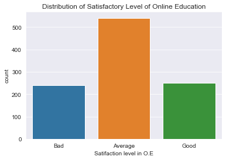

```python
# Distribution of variable of interest
print(online_review['Satifaction level in O.E'].value_counts(normalize=True)*100)
sns.countplot(data=online_review, x='Satifaction level in O.E').set(title='Distribution of Satisfactory Level of Online Education');
```

```
60.0     23.620523
80.0     21.103582
70.0     17.521781
50.0      8.906099
100.0     8.422072
40.0      7.550823
90.0      7.066796
20.0      3.581801
30.0      2.226525
Name: Performance in online, dtype: float64
```

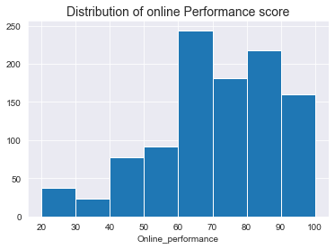

```python
# Distribution of online Performance score
print(online_review['Performance in online'].value_counts(normalize=True)*100)
bins = np.arange(20, online_review['Performance in online'].max()+10, 10)
plt.hist(data = online_review, x = 'Performance in online', bins = bins)
plt.xlabel('Online_performance')
plt.title('Distribution of online Performance score', fontsize=14);
```

Online performance seems to be generally above average with highest performace at 60%

```python
# Grouping of the Age column into category
bin_ages = [0,12,19,40]
bin_labels = ['children', 'teenagers', 'young_adults']
# Where  0 rep children, 1 rep teenagers, 2 rep young_adults
online_review['Age_levels'] = pd.cut(online_review['Age(Years)'], bin_ages, labels=bin_labels)
```

```
teenagers       52.758955
young_adults    46.853824
children         0.387222
Name: Age_levels, dtype: float64
```

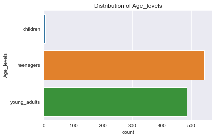

```python
print(online_review['Age_levels'].value_counts(normalize=True)*100)
sns.countplot(data=online_review, y='Age_levels').set(title='Distribution of Age_levels');
```

From this chart we can infer that the teenage population(gen Z) were more involved in online education as compared to the youg adult population

###### Let's start with some numerical variable including `Sleep time (Hours)`, `Study time (Hours)`, `Time spent on social media (Hours)`

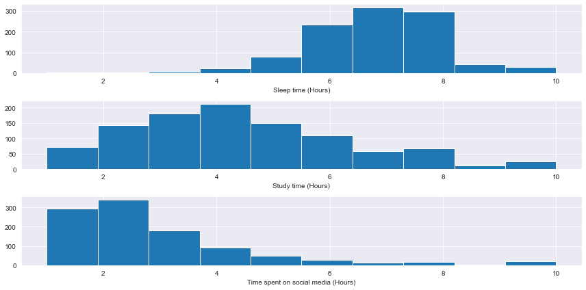

```python
# Plotting all three together (Sleep time (Hours), Study time (Hours), Time spent on social media (Hours))
fig, ax = plt.subplots(nrows=3, figsize = [12,6])

variables = ['Sleep time (Hours)', 'Study time (Hours)', 'Time spent on social media (Hours)']
for i in range(len(variables)):
    var = variables[i]
    ax[i].hist(data = online_review, x = var)
    ax[i].set_xlabel(var)
plt.tight_layout();
```

###### Let's also check some categorical variable including `Economic status`, `Home Location`, and `Device type used to attend classes`

```python
# print(online_review['Study time (Hours)'].value_counts(normalize=True)*100)
```

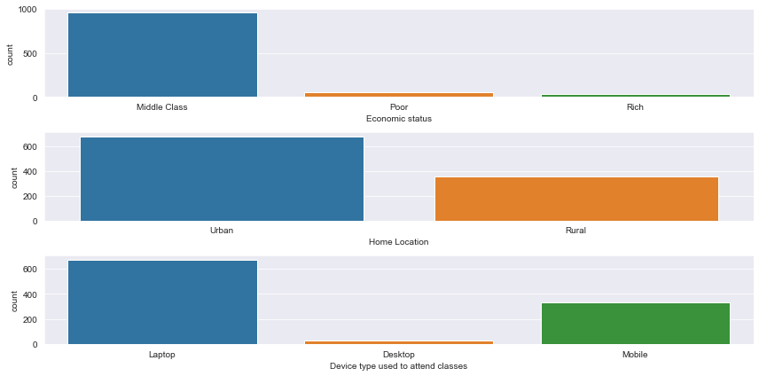

```python
# Plotting all three together (Economic status, Home Location, and Device type used to attend classes)
fig, ax = plt.subplots(nrows=3, figsize = [12,6])

sns.countplot(data=online_review, x='Economic status',  ax=ax[0])
sns.countplot(data=online_review, x='Home Location', ax=ax[1])
sns.countplot(data=online_review, x='Device type used to attend classes', ax=ax[2])

plt.tight_layout();
```

```python
# print(online_review['Home Location'].value_counts(normalize=True)*100)
```

Those in the middle class were more involved in the online education system, and majority where from the Urban areas as one would expect, with high prticipation from laptop users

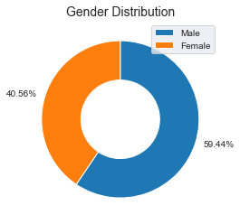

```python
# Plot of Gender distribution
gendercount = round(online_review['Gender'].value_counts(normalize=True)*100,2)
plt.pie(gendercount, labels=[f"{str(x)}%" for x in gendercount.values], startangle=90, counterclock = False, wedgeprops = {'width': 0.5});
plt.title('Gender Distribution', fontsize=14)
plt.legend(gendercount.index);
```

The chart shows us that the male gender were more involve in the online education compared to the female

```python
# Dropping few features
online_review.drop(['Average marks scored before pandemic in traditional classroom','min_average','max_average'],axis=1, inplace=True)
```

- A closer look at our variable of interest (satisfactory level) it can e oserved that about 50% of the participants satisfactory level was average.
- The teenage population were more involved in online education with about 53%, closely followed by young adult with approx. 47% while the children population is less than 1%
- Majority of the students studied for and average of 4 hours which accounted for 20.6% of the population
- Those residence in Urban areas had more participation of 65.7%
- The gender distribution showed 59.44% participation of the male gender while the female populationrecorded 40.56%

## Bivariate Exploration

```python
# CHecking for the number of unique value in each variable
online_review.nunique()
```

```
Gender                                            2
Home Location                                     2
Level of Education                                3
Age(Years)                                       24
Number of Subjects                               20
Device type used to attend classes                3
Economic status                                   3
Family size                                       9
Internet facility                                 5
Are you involved in any sports?                   2
Do elderly people monitor you?                    2
Study time (Hours)                               10
Sleep time (Hours)                               10
Time spent on social media (Hours)               10
Interested in Gaming?                             2
Have separate room for studying?                  2
Engaged in group studies?                         2
Online mode interaction                           5
Clearing doubts with faculties in online mode     5
Interested in?                                    3
Performance in online                             9
Satifaction level in O.E                          3
Performance in classroom                         10
Age_levels                                        3
dtype: int64
```

```python
numeric_vars = ['Age(Years)', 'Study time (Hours)', 'Sleep time (Hours)','Time spent on social media (Hours)','Performance in online','Performance in classroom']
categoric_vars = ['Gender', 'Home Location', 'Level of Education','Device type used to attend classes','Economic status','Internet facility',
    'Have separate room for studying?', 'Engaged in group studies?','Online mode interaction','Clearing doubts with faculties in online mode',
    'Interested in?','Satifaction level in O.E','Age_levels']
```

##### Investigating Correlation between Performance in classroom & Online Performance

```
Correlation between Performance in classroom & Performance in online:
0.012434081251881663
```

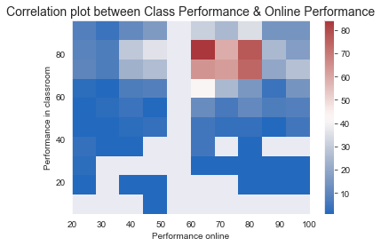

```python
print("Correlation between Performance in classroom & Performance in online: ")
print(online_review['Performance in online'].corr(online_review['Performance in classroom']))
plt.hist2d(data = online_review, x = 'Performance in online', y= 'Performance in classroom', cmin=0.5, cmap='vlag');
plt.colorbar();
plt.title('Correlation plot between Class Performance & Online Performance', fontsize=14)
plt.xlabel('Performance online')
plt.ylabel('Performance in classroom');
```

##### Plot of Online performance versus Satisfaction level in online education

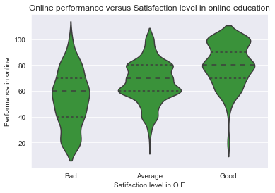

```python
color_base= sns.color_palette()[2]
sns.violinplot(data=online_review, x = 'Satifaction level in O.E', y= 'Performance in online',color=color_base, inner='quartiles').set(title='Online performance versus Satisfaction level in online education');
```

From the violinplot above we can observe that the feedback on satisfaction level is subjective to the individual involved, while the average score from the satisfaction level Bad is 60%, we have that for average as 70% and Good as 80%. Whereas they were individuals withh 100% in all satisfaction

Inference: This suggest that the online performance was not the only yardstick for the comment on satisfaction level in online education

##### Plot of Online performance versus Number of Subjects

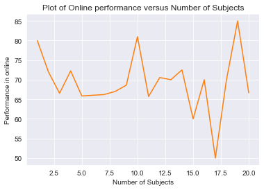

```python
color_base1= sns.color_palette()[1]
sns.lineplot(data=online_review, y ='Performance in online', x= 'Number of Subjects', color=color_base1, ci=None).set(title='Plot of Online performance versus Number of Subjects');
```

From the chart above it can be seen that the volume of the subjects taken does not affect the performance of the students

##### Plotting all three together (Internet facility, Clearing doubts with faculties in online mode, and Online mode interaction) against Satisfaction level

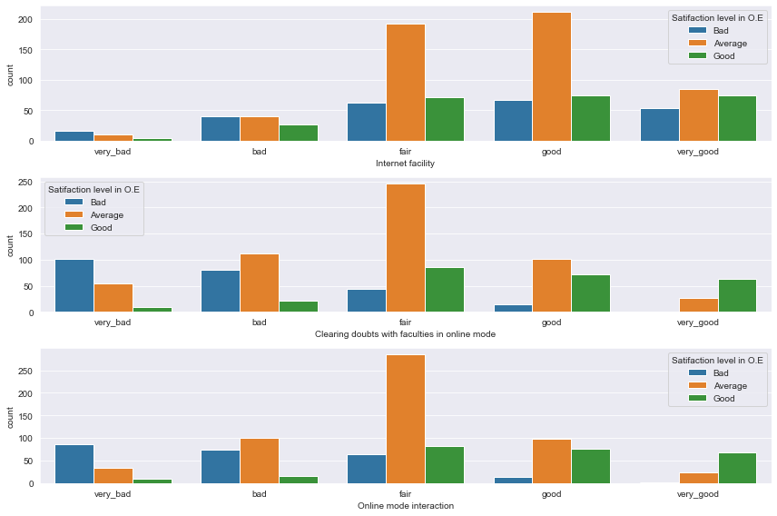

```python
fig, ax = plt.subplots(nrows=3, figsize = [12,8])

sns.countplot(data=online_review, x='Internet facility', hue='Satifaction level in O.E',  ax=ax[0])
sns.countplot(data=online_review, x='Clearing doubts with faculties in online mode', hue='Satifaction level in O.E', ax=ax[1])
sns.countplot(data=online_review, x='Online mode interaction', hue='Satifaction level in O.E', ax=ax[2])

plt.tight_layout();
```

From the chart of plot of internet facility as compared to satisfaction level, we can see that there was a low participation in the very bad and bad locations. While the average satisfaction level seems to be quite dominant accross it suggest that internet facilty is not an absolute determinant of the satisfactio level.

Inference: This suggest that being able to clear doubts with faculties in online mode & online mode interaction situation are other key predictors for the satisfaction in the online education scheme.

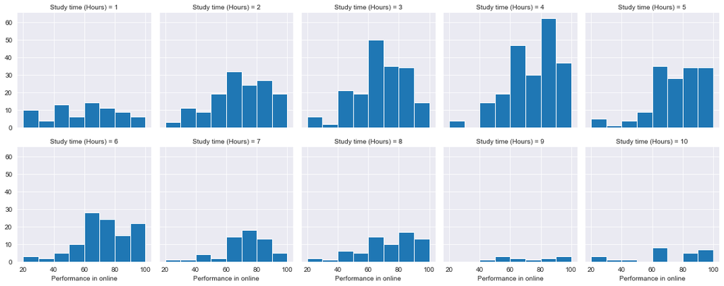

```python
bins=np.arange(20, 100+10, 10)
f = sns.FacetGrid(data = online_review, col='Study time (Hours)', col_wrap= 5)
f.map(plt.hist, 'Performance in online', bins=bins);
```

From the chart we will notice that the number of of study hours is not directly proportional to the performance online has we have the highest from a students that spent 4 hours of study time.

```
Practical    42.497580
Both         33.591481
Theory       23.910939
Name: Interested in?, dtype: float64
```

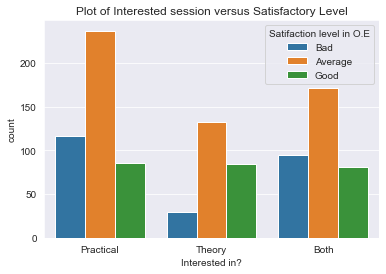

```python
print(online_review['Interested in?'].value_counts(normalize=True)*100)
sns.countplot(data=online_review, x='Interested in?', hue='Satifaction level in O.E').set(title='Plot of Interested session versus Satisfactory Level');
```

Students were more interested in practical subject compared to Theory, while a significant percentage of aprroximately 34% students takes both

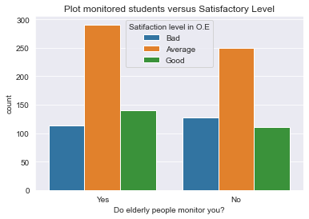

```python
sns.countplot(data=online_review, x='Do elderly people monitor you?', hue='Satifaction level in O.E').set(title='Plot monitored students versus Satisfactory Level');
```

There is slight improvement in satisfaction level for those who had elderly people (more likle a mentor/instructor) monitor their involvement in online education

Some of the relationship investigated in this section include:

- Correlation between Performance in classroom & Online Performance
- Plot of Online performance versus Satisfaction level in online education
- Plot of Online performance versus Number of Subjects
- Plotting all three together (Internet facility, Clearing doubts with faculties in online mode, and Online mode interaction) against Satisfaction level

And some of the inference made based on observation include

- Online performance was not the only yardstick for the comment on satisfaction level in online education (in other words online performance is not directly proportional to the feedback)
- Being able to clear doubts with faculties in online mode & online mode interaction situation are other key predictors for the satisfaction in the online education scheme

## Multivariate Analysis

##### Correlation between Satisfaction level in Online Education, Online performance and those monitored by elderly people

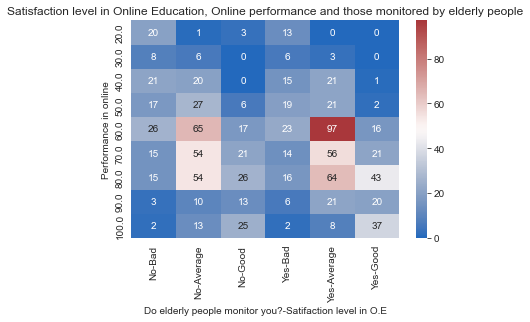

```python
# Grouping data using Satisfaction level, Online performance and Do elderly people monitor you?
grouped = online_review.groupby([online_review['Performance in online'], 'Do elderly people monitor you?', 'Satifaction level in O.E']).size().reset_index(name='count')
# Fixing dataset layout
grouped = grouped.pivot(index='Performance in online', columns=['Do elderly people monitor you?', 'Satifaction level in O.E'], values = 'count').dropna()
# Plotting the heatmap
plot = sns.heatmap(grouped, annot=True, cmap='vlag').set(title='Satisfaction level in Online Education, Online performance and those monitored by elderly people');
```

The result of the correlation plot shows a level of increase aove the 60% online performance score for students who had elderly people monitor them (we could liken that to mentor or offline instructors)

##### Correlation between Satisfaction level in Online Education, Online performance and those that have separate room for studying

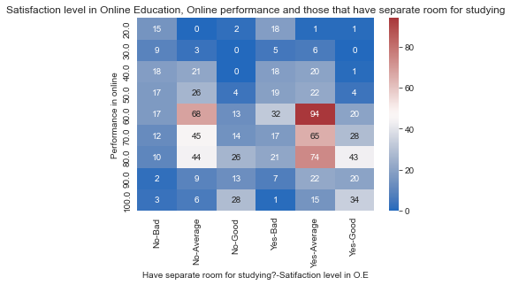

```python
# Grouping data using Satisfaction level, Online performance and Gender
grouped_2 = online_review.groupby([online_review['Performance in online'], 'Have separate room for studying?', 'Satifaction level in O.E']).size().reset_index(name='count')
grouped_2 = grouped_2.pivot(index='Performance in online', columns=['Have separate room for studying?', 'Satifaction level in O.E'], values = 'count')

# Plotting the heatmap
plot = sns.heatmap(grouped_2, annot=True, cmap='vlag').set(title='Satisfaction level in Online Education, Online performance and those that have separate room for studying');
```

The result of the correlation plot shows a level of increase aove the 60% online performance score for students who had separate room for studying.

##### Correlation between Satisfaction level in Online Education, Online performance and those that are involved in any sports

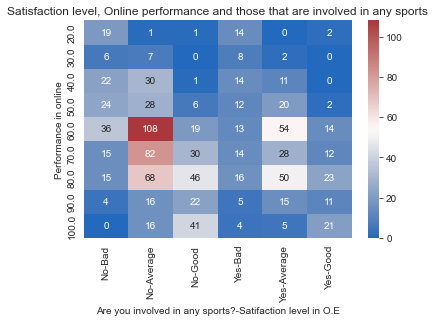

```python
# Grouping data using Satisfaction level, Online performance and those that are involved in any sports
grouped_3 = online_review.groupby([online_review['Performance in online'], 'Are you involved in any sports?', 'Satifaction level in O.E']).size().reset_index(name='count')
grouped_3 = grouped_3.pivot(index='Performance in online', columns=['Are you involved in any sports?', 'Satifaction level in O.E'], values = 'count')

# Plotting the heatmap
plot = sns.heatmap(grouped_3, annot=True, fmt='.0f', cmap='vlag').set(title='Satisfaction level, Online performance and those that are involved in any sports');
```

The result of the correlation plot shows a level of increase aove the 60% online performance score for students who were not involved in any sports with focus on the average and good satisfaction levels

##### Plot of Performance in online against Study time (Hours) for each Satisfactory level

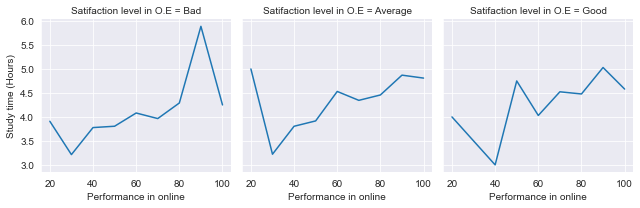

```python
mult = sns.FacetGrid(data = online_review, col='Satifaction level in O.E')
mult.map(sns.lineplot, 'Performance in online', 'Study time (Hours)',ci=None);
```

We see from this plot that despite the high online performance score some students Satisfactory level was still bad which could be a result of other features

##### Plot of Performance in online against Study time (Hours) for each Home Location

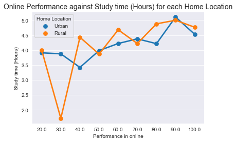

```python
sns.pointplot(data=online_review, x ='Performance in online', y= 'Study time (Hours)', hue='Home Location', ci=None)
plt.title('Online Performance against Study time (Hours) for each Home Location', fontsize=14);
```

##### Plot of Performance in online against Study time (Hours) for those with separate study room

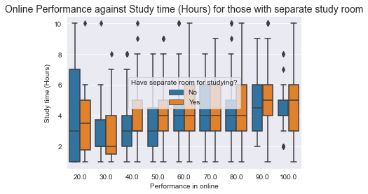

```python
sns.boxplot(data=online_review, x ='Performance in online', y= 'Study time (Hours)', hue='Have separate room for studying?')
plt.title('Online Performance against Study time (Hours) for those with separate study room', fontsize=14);
```

##### Plot of Online performance against Satifaction level in Online Education for each Gender

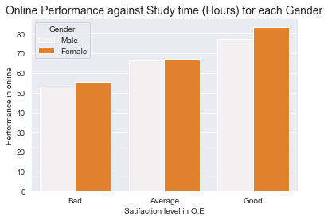

```python
sns.barplot(data=online_review, x = 'Satifaction level in O.E', y= 'Performance in online',hue='Gender',color=color_base1, ci=None)
plt.title('Online Performance against Study time (Hours) for each Gender', fontsize=14);
```

Some of the relationship investigated in this section include:

- Correlation between Satisfaction level in Online Education, Online performance and those monitored by elderly people
- Correlation between Satisfaction level in Online Education, Online performance and those that have separate room for studying
- Correlation between Satisfaction level in Online Education, Online performance and those that are involved in any sports
- Plot of Performance in online against Study time (Hours) for each Satisfactory level
- Plot of Performance in online against Study time (Hours) for each Home Location
- Plot of Performance in online against Study time (Hours) for those with separate study room
- Plot of Online performance against Satifaction level in Online Education for each Gender

Few things to note in this section

- The result of the correlation plot shows a level of increase aove the 60% online performance score for students who had elderly people monitor them (we could liken that to mentor or offline instructors)
- The result of the correlation plot shows a level of increase aove the 60% online performance score for students who had separate room for studying.
- The result of the correlation plot shows a level of increase aove the 60% online performance score for students who were not involved in any sports with focus on the average and good satisfaction levels
- Despite the distribution of male gender being higher than the female, the chart below shows that the female gender performed better across all satisfactory level also.